# Análisis de Clusters y Segmentación

T. Evgeniou, INSEAD (traducción por Eduardo Aguilar)

# ¿Para qué es esto?

En Analítica frecuentemente tenemos conjuntos de datos muy grandes (muchas observaciones - “filas en el archivo plano”), las cuales son similares entre ellas por lo tanto quisieramos organizarlas en unos cuantos clusters con observaciones similares dentro de cada uno de ellos. Por ejemplo, en el caso de los datos de consumidores, aunque podamos tener datos de millones de consumidores, esos consumidores pueden pertenecer a unos pocos segmentos: consumidores similares dentro de cada segmento pero diferentes entre segmentos. Frecuentemente necesitaremos analizar cada segmento de forma separada, ya que ellos se comportan de modo diferente (por ej: diferentes segmentos de mercado pueden diferir en sus preferencias de productos y patrones de comportamiento).

En tales situaciones, para identificar los segmentos en los datos uno puede utilizar técnicas estadísticas ampliamente conocidas llamadas técnicas de **Clusterización**. Basado en como se definen las “similitudes” y “diferencias” entre observaciones (por ej: clientes o activos), las cuales pueden también ser definidas matemáticamente usando **métricas de distancia**, uno puede encontrar diferentes soluciones de segmentación. Un ingrediente clave de clusterización y segmentación es precisamente la definición de esas medidas de distancia(entre observaciones), las cuales necesitan ser definidas creativamente basadas en el conocimiento contextual y no solo utilizando la “caja negra” de ecuaciones y técnicas matemáticas.

> Las técnicas de clusterización son utilizadas para agrupar datos/observaciones en unos pocos segmentos de modo que los datos dentro de cada segmento sean similares entre sí mientras que los datos entre segmentos difieran. Definir lo que queremos decir por observaciones “similares” o “diferentes” es una parte clave de el análisis de clusters lo cual frecuentemente requiere mucho análisis contextualy creatividad mas allá de lo que las técnicas estadísticas pueden utilizar.

El análisis de clusters es utilizado en muchas aplicaciones. Por ejemplo, puede ser utilizado para identificar segmentos de consumidores, o grupos de productos competitivos, o grupos de activos cuyos precios pueden estar cointegrados(moverse juntos), o para segmentaciones geodemográficas, etc. En general, frecuentemente es necesario dividir nuestros datos en segmentos y realizar un subsecuente análisis dentro de cada segmento para desarrollar (potencialmente más refinado) conclusiones de cada segmento en específico. Esto puede ser el caso si no hay segmentos que sean intuitivamente “naturales”" en nuestros datos.

# Clusterización y Segmentación usando un ejemplo

En estos apuntos revisaremos el proceso de clusterización y segmentación usando un conjunto de datos muy simple que describe las actitudes de las personas hacia comprar en un centro comercial. Como este es un conjunto de datos pequeños, uno podría incluso explorar “manualmente” los datos para encontrar “visualmente” segmentos de consumidores (lo cual es muy factible para este pequeño grupo de datos, aunque la clusterización es en general un problema muy difícil incluso cuando el número de datos es muy pequeño).

Antes de leer más, no trate de pensar cuáles segmentos podrían definirse utilizando estos datos. Como siempre, usted verá en este relativamente sencillo caso que no es tan obvio lo que los segmentos deben ser, y usted probablemente no estará de acuerdo con sus colegas acerca de ellos: el propósito después de todo es dejar a los números y estadísticas ayudarnos a ser más **objetivos y estadísticamente correctos**.

## La “decisión de negocios”

El equipo gerencial de un gran centro comercial quisiera entender los tipos de personas que visitan o potencialmente visiten su centro comericial. Ellos tienen razones para creer que hay unos pocos segmentos de mercado, y están considerando diseñar y posicionar los servicios del centro comercial para atraer principalmente a los segmentos más rentables, o para diferenciar sus servicios (por ej: invitaciones a eventos, descuentos, etc.) entre los segmentos de mercado.

## Los datos

Para hacer esas decisiones, el equipo gerencial realiza una investigación de mercados de unos pocos consumidores potenciales. En este caso era una pequeña encuesta a pocas personas, en donde cada persona contestó 6 preguntas actitudinales y una pregunta concerniente a que tan seguido visitaban el centro comercial, todo en una escala del 1 al 7, así como una pregunta concerniente a su ingreso familiar:

| Nombre | Descripción | Escala |
| --- | --- | --- |
| V1 | Comprar es Divertido | 1-7 |
| V2 | Comprar es malo para su presupuesto | 1-7 |
| V3 | Yo combino comprar con comer | 1-7 |
| V4 | Yo trato de obtener las mejores productos | 1-7 |
| V5 | No me interesa ir de compras | 1-7 |
| V6 | Usted puede ahorrar mucho dinero comparando precios | 1-7 |
| Ingresos | El ingreso familiar del entrevistado | Dollars |
| Mall.Visits | ¿Qué tan seguido visita el centro comercial? | 1-7 |

Cuarenta personas respondieron a estas 6 preguntas. Estas son las respuestas para las primeras 10 personas:

| ID | V1 | V2 | V3 | V4 | V5 | V6 | Income | Mall.Visits |
| --- | --- | --- | --- | --- | --- | --- | --- | --- |
| 1 | 6 | 4 | 7 | 3 | 2 | 3 | 60000 | 3 |
| 2 | 2 | 3 | 1 | 4 | 5 | 4 | 30000 | 1 |
| 3 | 7 | 2 | 6 | 4 | 1 | 3 | 70000 | 3 |
| 4 | 4 | 6 | 4 | 5 | 3 | 6 | 30000 | 7 |
| 5 | 1 | 3 | 2 | 2 | 6 | 4 | 60000 | 1 |
| 6 | 6 | 4 | 6 | 3 | 3 | 4 | 50000 | 2 |
| 7 | 5 | 3 | 6 | 3 | 3 | 4 | 65000 | 3 |
| 8 | 7 | 3 | 7 | 4 | 1 | 4 | 55000 | 4 |
| 9 | 2 | 4 | 3 | 3 | 6 | 3 | 70000 | 0 |
| 10 | 3 | 5 | 3 | 6 | 4 | 6 | 25000 | 6 |

Veremos unas cuantas estadísticas descriptivas en los datos posteriores, cuando entremos en el análisis estadístico.

¿Cómo puede la compañía segmentar esas 40 personas? ¿Hay de verdad segmentos en este mercado? Veamos **un** proceso de clusterización y segmentación, el propósito de este reporte.

## Un Proceso de Clusterización y Segmentación

Como siempre:

> Es importante recordar que los proyectos de Data Analytics requieren un delicado balance entre experimentación, intuición, pero también seguir un proceso (de vez en cuando) para evitar ser engañado por la aletoriedad y “encontrar datos y patrones” que estén explicados principalmente por nuestros propios sesgos y no por hechos en sí.

No hay *un único* proceso para clusterización y segmentación. Sin embargo, tenemos que empezar por algo, así que usaremos el siguiente proceso:

# Clusterización y Segmentación en 8 pasos

1. Confirmar que los datos son métricos
2. Escalar los datos
3. Seleccionar las Variables de Segmentación
4. Definir la medida de similitud
5. Visualizar Distancias entre Pares
6. Método y Número de Segmentos
7. Perfil e interpretación de los segmentos
8. Análisis de Robustes

Sigamos esos pasos.

## Paso 1: Confirmar que los datos son métricos

Aunque uno puede sergmentar datos incluso si estos no son métricos, muchos métodos estadísticos disponibles para clusterización requieren que los datos sean así: esto significa no solamente que los datos sean números, pero también que los números tengan un significado numérico, esto es, 1 es menor que 2, que es menor a 3. La principal razón de esto es que uno necesita definir distancias entre observaciones (ver paso 4 abajo), y frecuentemente (“caja negra” matemática) distancias (por ej: “Distancia Euclídea”) son definidas solo por datos métricos.

Sin embargo, potencialmente se podrían definir medidas para datos no métricos. Por ejemplo, si nuestros datos son nombres de personas, uno simplemente podría definir la distancia entre dos personas como 0 cuando tienen el mismo nombre y 1 en cualquier otro caso. Esto es porque, aunque la mayoría de métodos estadísticos disponibles (los cuales usaremos más adelante) requieren que los datos sean métricos, no es una condición necesaria mientras estemos dispuestos a “intervenir la clusterización manualmente, por ejemplo, definiendo medidas de distancia entre nuestras observaciones de forma manual”. Mostraremos un ejemplo simple de tal intervención manual más adelante. Es posible (en este reporte).

> En general, la “mejor práctica” para segmentación es definir creativamente métricas de distancia entre nuestras observaciones.

En nuestro caso los datos son métricos, así que continuaremos el siguiente paso. Pero antes de hacerlo, chequearemos las estadísticas descriptivas de nuestros datos para obtener, como siempre, un mejor entendimiento de los mismos. Nuestros datos tienen las siguientes estadísticas descriptivas:

|  | min | 25 percent | median | mean | 75 percent | max | std |
| --- | --- | --- | --- | --- | --- | --- | --- |
| ID | 1 | 10.75 | 20.5 | 20.50 | 30.25 | 40 | 11.69 |
| V1 | 1 | 2.00 | 4.0 | 3.85 | 5.25 | 7 | 1.87 |
| V2 | 2 | 3.00 | 4.0 | 4.10 | 5.00 | 7 | 1.39 |
| V3 | 1 | 2.00 | 4.0 | 3.95 | 6.00 | 7 | 1.99 |
| V4 | 2 | 3.00 | 4.0 | 4.10 | 5.25 | 7 | 1.50 |
| V5 | 1 | 2.00 | 3.5 | 3.45 | 4.25 | 7 | 1.74 |
| V6 | 2 | 3.00 | 4.0 | 4.35 | 5.25 | 7 | 1.48 |
| Income | 25000 | 30000.00 | 42500.0 | 46000.00 | 60000.00 | 80000 | 17216.57 |
| Mall.Visits | 0 | 2.00 | 3.0 | 3.25 | 4.25 | 7 | 1.94 |

> Note que se puede llevar mucho tiempo en obtener una idea de los datos basado en simples estadísticas descriptivas y visualizaciones: la buena analítica de datos requiere que entendamos nuestros datos muy bien.

## Paso 2: Escalar los datos

Que haya variables con escalas muy diferentes puede crear problemas: **la mayoría de “resultados” pueden ser derivados de los valores más grandes**, más de lo que desearíamos. Para evitar esos problemas, uno tiene que considerar si **estandarizar los datos** o no transformandolos a media cero y desviación estándar 1 (por ej: `scaledIncome` `=` `(Income-mean(Income))` `/` `sd(Income)`), o escalar los datos entre cero y 1 (por ej: `scaledIncome` `=` `(Income-min(Income))` `/` `(max(Income)-min(Income))`). Este es un ejemplo de código en R para el primer enfoque, si deseamos estandarizar todos los atributos:

```r
# Función para estandarizar datos
estandarizar <- function(r) {
    if (sd(r) != 0)
        res = (r - mean(r))/sd(r) else res = 0 * r
    res
}

# Estandarizando dataset completo
ProjectData_scaled = apply(ProjectData, 2, estandarizar)
```

Notemos ahora las estadísticas descriptivas de los datos escalados:

|  | min | 25 percent | median | mean | 75 percent | max | std |
| --- | --- | --- | --- | --- | --- | --- | --- |
| ID | -1.67 | -0.83 | 0.00 | 0 | 0.83 | 1.67 | 1 |
| V1 | -1.52 | -0.99 | 0.08 | 0 | 0.75 | 1.68 | 1 |
| V2 | -1.51 | -0.79 | -0.07 | 0 | 0.65 | 2.08 | 1 |
| V3 | -1.49 | -0.98 | 0.03 | 0 | 1.03 | 1.54 | 1 |
| V4 | -1.40 | -0.73 | -0.07 | 0 | 0.77 | 1.93 | 1 |
| V5 | -1.41 | -0.83 | 0.03 | 0 | 0.46 | 2.04 | 1 |
| V6 | -1.59 | -0.91 | -0.24 | 0 | 0.61 | 1.79 | 1 |
| Income | -1.22 | -0.93 | -0.20 | 0 | 0.81 | 1.97 | 1 |
| Mall.Visits | -1.67 | -0.64 | -0.13 | 0 | 0.51 | 1.93 | 1 |

Como esperábamos todas las variables tienen media 0 y desviación estándar 1.

Mientras este es un paso típicamente necesario, uno siempre tiene que hacerlo con mucho cuidado: a veces usted quisiera que sus conclusiones analíticas estén basadas principalmente por pocos atributos que tomen valores grandes; otras veces tener atributos con diferentes escalas pueden implicar algo acerca de esos atributos. En muchos casos uno puede omitir el paso 2 para algunos atributos.

## Paso 3: Seleccionar las Variables de Segmentación

La decisión de cuales variables utilizar para la clusterización es una **decisión críticamente importante** que tendrá un impacto en la solución de clusterización. Entonces necesitamos pensar cuidadosamente acerca de las variables que elegiremos para la clusterización. Una buena investigación explorativa que puede darnos una idea de que variables son capaces de distinguir personas o productos o activos o regiones es crítico. Claramente estees un paso donde mucho conocimiento contextual, creatividad, y experimentación/iteraciones son necesarias.

En nuestro caso, podemos utilizar 6 preguntas actitudinales para segmentación, y las restantes 2 (Ingresos y visitas al mall) para perfilarlos más adelante.

## Paso 4: Definir una medida de similitud

Recordemos que el propósito de clusterizar y segmentar es agrupar observaciones basadas en que tan similares son. Es entonces **crucial** que tengamos un buen entendimiento de que hace que dos observaciones (por ej: clientes, productos, compañías, activos, inversiones, etc.) sean “similares”.

> Si el usuario no tiene un buen entendimiento de que hace que dos observaciones (por ej: clientes, productos, compañías, activos, inversiones, etc.) sean “similares”", ningún método estadístico será capaz de descubrir la respuesta a esa pregunta.

La mayoría de métodos estadísticos para clusterización y segmentación usan medidas matemáticas de distancia comunes. Típicamente las medidas son, por ejemplo, la **distancia Euclídea** o la distancia **Manhattan** (ver `help(dist)` en R para más ejemplos).

> Hay literalmente miles de rigurosas definiciones matemáticas de distancia entre observaciones/vectores! Además, cómo notará arriba, el usuario podría manualmente definir dichas métricas de distancias, como mostramos en el ejemplo de abajo - note sin embargo, que para hacerlo uno debe de asegurarse que las distancias definidas sean en efecto “válidas” (enm un sentido matemático, un tema más allá del alcance de estos apuntes).

En nuestro caso exploramos dos métricas de distancia: la comúnmente utilizada **distancia Euclídea** así como la simple que definimos manualmente.

| 1 | 2 | 3 | 4 | 5 | 6 | 7 | 8 | 9 | 10 |
| --- | --- | --- | --- | --- | --- | --- | --- | --- | --- |
| 0 |  |  |  |  |  |  |  |  |  |
| 8 | 0 |  |  |  |  |  |  |  |  |
| 3 | 8 | 0 |  |  |  |  |  |  |  |
| 6 | 6 | 7 | 0 |  |  |  |  |  |  |
| 8 | 3 | 9 | 7 | 0 |  |  |  |  |  |
| 2 | 7 | 3 | 4 | 7 | 0 |  |  |  |  |
| 2 | 6 | 3 | 5 | 6 | 1 | 0 |  |  |  |
| 2 | 9 | 2 | 6 | 9 | 3 | 3 | 0 |  |  |
| 7 | 3 | 8 | 6 | 2 | 6 | 5 | 8 | 0 |  |
| 7 | 4 | 7 | 2 | 6 | 6 | 6 | 7 | 5 | 0 |

Notemos por ejemplo que si usamos, por ejemplo, la distancia Manhattan, esas distancias cambian así:

| 1 | 2 | 3 | 4 | 5 | 6 | 7 | 8 | 9 | 10 |
| --- | --- | --- | --- | --- | --- | --- | --- | --- | --- |
| 0 |  |  |  |  |  |  |  |  |  |
| 16 | 0 |  |  |  |  |  |  |  |  |
| 6 | 16 | 0 |  |  |  |  |  |  |  |
| 13 | 13 | 15 | 0 |  |  |  |  |  |  |
| 17 | 5 | 19 | 16 | 0 |  |  |  |  |  |
| 3 | 13 | 7 | 10 | 14 | 0 |  |  |  |  |
| 5 | 11 | 7 | 10 | 12 | 2 | 0 |  |  |  |
| 5 | 15 | 3 | 14 | 18 | 6 | 6 | 0 |  |  |
| 12 | 6 | 16 | 13 | 5 | 11 | 11 | 17 | 0 |  |
| 16 | 10 | 18 | 5 | 13 | 13 | 13 | 17 | 10 | 0 |

Definamos ahora nuestra propia métrica de distancia, como un ejemplo. Digamos que el equipo gerencial cree que dos consumidores son similares si ellos no difieren en sus ratings de preguntas actitudinales en más de 2 puntos. Podemos manualmente asignar la distancia de 1 para cada pregunta por la cual dos clientes dieron una respuesta que difiere en más de 2 puntos, y 0 para lo contrario. Es fácil escribir esta función de distancia en R:

```r
# Función de distancia personalizada
My_Distance_function <- function(x, y) {
    sum(abs(x - y) > 2)
}
```

Así se verían las distancias entre los entrevistados ahora:

| 1 | 2 | 3 | 4 | 5 | 6 | 7 | 8 | 9 | 10 |
| --- | --- | --- | --- | --- | --- | --- | --- | --- | --- |
| 0 |  |  |  |  |  |  |  |  |  |
| 3 | 0 |  |  |  |  |  |  |  |  |
| 0 | 3 | 0 |  |  |  |  |  |  |  |
| 2 | 2 | 3 | 0 |  |  |  |  |  |  |
| 3 | 0 | 3 | 4 | 0 |  |  |  |  |  |
| 0 | 2 | 0 | 0 | 3 | 0 |  |  |  |  |
| 0 | 2 | 0 | 1 | 3 | 0 | 0 |  |  |  |
| 0 | 3 | 0 | 3 | 3 | 0 | 0 | 0 |  |  |
| 3 | 0 | 3 | 2 | 0 | 3 | 3 | 3 | 0 |  |
| 4 | 0 | 5 | 0 | 1 | 3 | 2 | 3 | 2 | 0 |

En general se dee dedicar mucho pensamiento creativo y análisis explorativo a esta parte, y como siempre uno podría necesitar volver a este paso incluso después de finalizar por completo el proceso de segmentación- múltiples veces.

## Paso 5: Visualizar las Distancias entre pares

Habiendo definido que significa que “dos observaciones son similares”, el siguiente paso es obtener un primer entendimiento de los datos a traves de visualizaciones por ejemplo de atributos individuales así como de distancias entre observaciones (usando varias métricas de distancia). Si hay en efecto múltiples segmentos en nuestros datos, algunos de esas gráficas deberían mostrar “montañas y valles” con las montañas teniendo potencial de conformar segmentos.

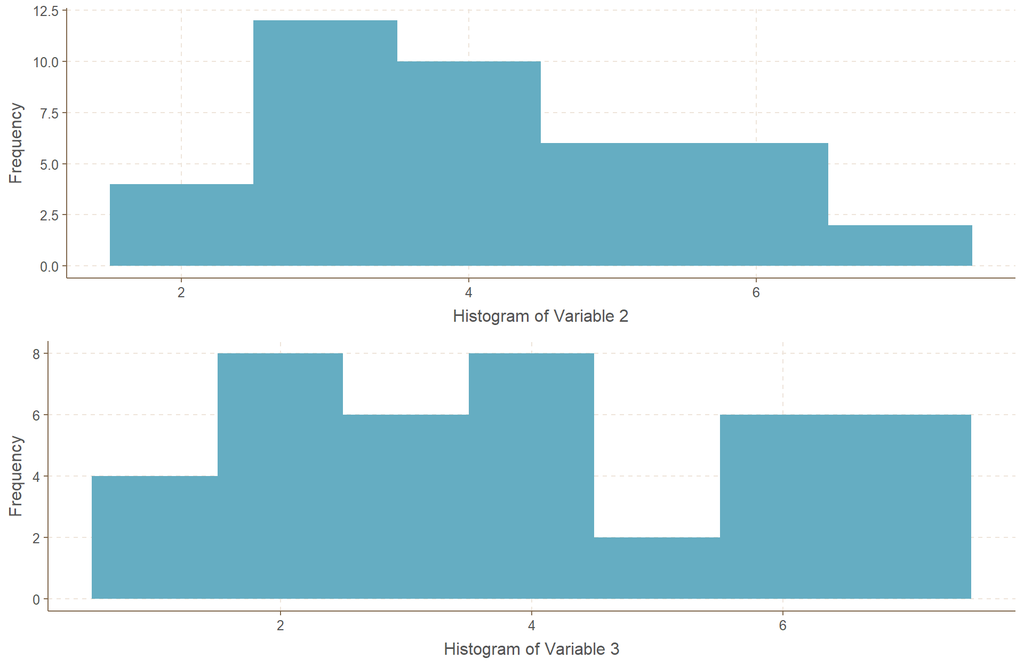

En este momento estamos usando el parámetro de distancia euclidean, si usted quiere cambiarlo a otra medida de distancia debe cambiarlo previamente:

El siguiente es el histograma de distancias entre observaciones para la medida de distancia actual:

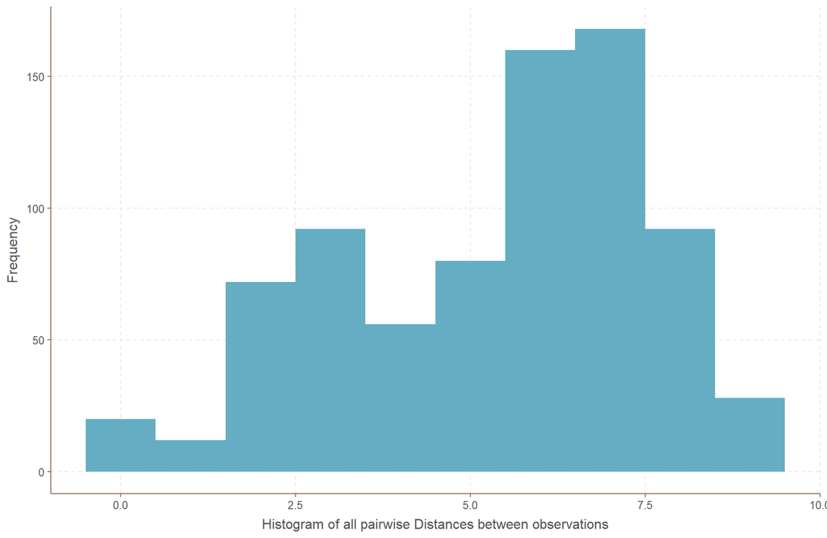

> La visualización es muy importante para data analytics, ya que esta puede proveerun primer entendimiento de los datos.

## Paso 6: Método y Número de Segmentos

Hay muchos métodos estadísticos para clusterización y segmentación. En la práctica uno puede usar varias opciones para luego eventualmente seleccionar la solución que es estadísticamente más robusta (ver el último paso abajo), interpretable, y accionable - entre otros criterios.

En estos apuntes usaremos principalmente dos métodos: **Método de Clusterización Kmedias (Kmeans)** y **Método de Clusterización Jerárquica**. Cómo todos los métodos de clusterización, estos dos también requieren que hayamos decidido cómo medir la distancia/similitud entre nuestras observaciones. Explicar cómo funcionan estos métodos está fuera del contenido de este curso. La única diferencia a remarcar es que Kmeans requiere que el usuario defina cuántos segmentos se crearán, mientras que la clusterización jerárquica no.

Usemos primero el método de **Clusterización Jerárquica**, ya que no sabemos cuantos segmentos hay en nuestros datos. La clusterización Jerárquica es un método que también nos ayuda a visualizar como se deben agrupar los datos entre si. Este genera un gráfico llamado **Dendograma** el cual es útil para visualización - pero debe ser usado con cuidado. Por ejemplo, en este caso el dendograma, usando la métrica de distancia euclideande los pasos anterioresy la opción de clusterización jerárquica ward.D (ver más abajo así como `help(hclust)` en R para más información), es como sigue:

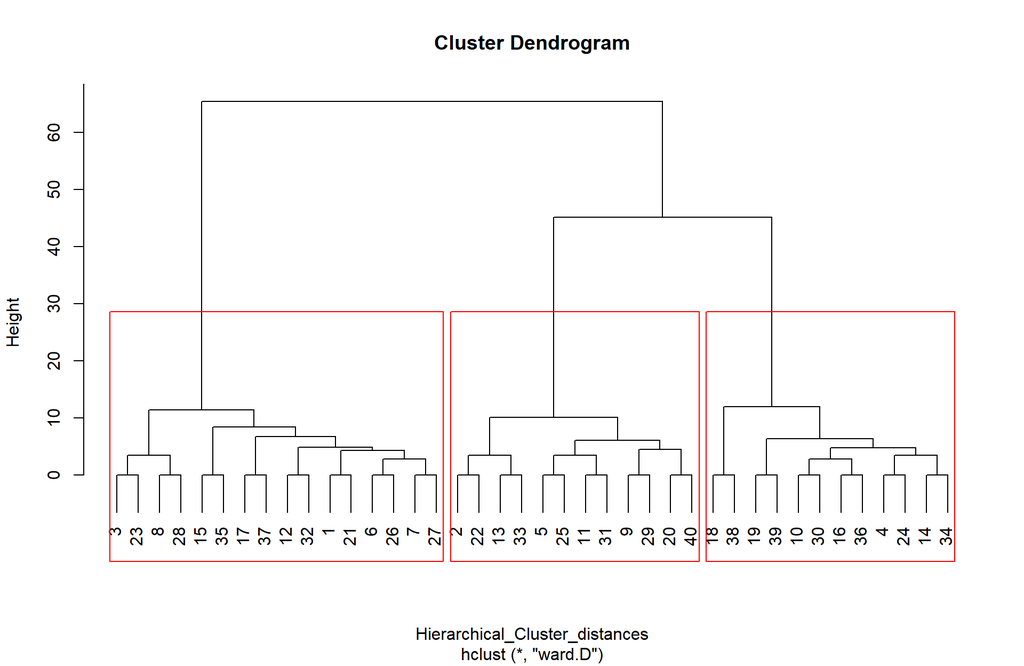

El Dendograma indica cómo este método de clusterización funciona: las observaciones son “agrupadas juntas”, empezando desde pares de observaciones individuales que son las más cercanas a ellas y fusionando grupos pequeños en grupos más grandes dependiendo de que grupos son los más cercanos entre sí. Eventualmente todos nuestros datos se fusionarán en un segmento. Las medidas de las ramas del árbol indican que los clusters abajo son muy diferentes. Como esperábamos, las medidas de las ramas del árbol incrementan a medida lo recorremos de las hojas finales a la raiz: el método fusiona datos desde los más cercanos hasta los más lejanos.

Los Dendogramas son una herramienta de visualización muy útil para la segmentación, incluso si el número de observaciones es muy alto, el árbol típicamente crece logarítmicamente con el número de datos. Sin embargo, esto puede ser engañoso. Notemos que una vez dos observaciones son fusionadas en el mismo segmento estas permanecen en el mismo segmento en todo el árbol. Esta “rigidez” del método de Clusterización Jerárquica puede llevar a segmentaciones que son subóptimas en muchas formas. Sin embargo, los dendogramas son útiles en práctica para ayudarnos a entender los datos, incluyendo el potencial número de segmentos que tenemos en nuestros datos. Además, hay varias formas de construir dendogramas, no solamente dependendiendo de la métrica de distancia que definimos en etapas anteriores, pero también dependiendo de como son agregados los datos en clusters (ver `help(hclust)` en R, por ejemplo, la cual provee las siguientes opciones para construir el árbol: “ward”, “single”, “complete”, “average”, “mcquitty”, “median” o “centroid”).

Podemos también graficar las “distancias” recorridas antes que necesitemos fusionar cualquiera de los clusters de menor tamaño en uno más grande - las medidas de las ramas del árbol que vinculan los clusters a medida se recorre el árbol desde las hojas hasta su raiz. Si tenemos n observaciones, esta gráfica tiene n-1 números.

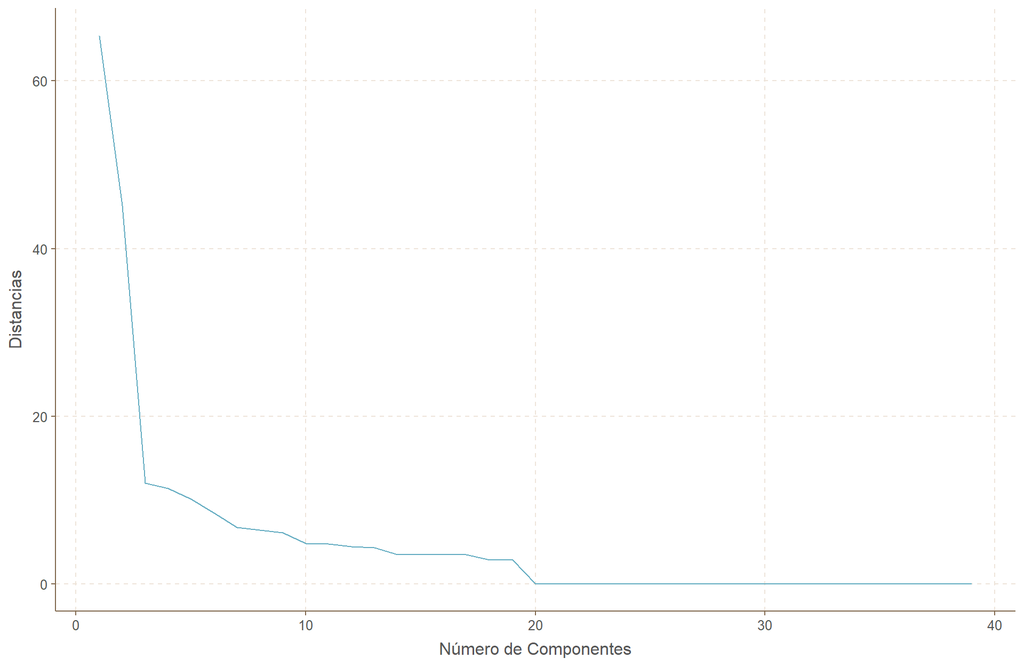

Como regla de oro, uno puede seleccionar el número de clusters como el “codo” de la gráfica: el lugar del árbol donde, si recorremos el árbol desde las horas hasta su raiz, necesitamos hacer el “salto más largo” antes de fusionarse con segmentos en ese nivel. Por supuesto que el número de real segmentos pude ser muy diferente del cual esta regla indica: en la práctica podemos explorar diferenes números de segmentos, posiblemente empezando por lo que el dendograma de la clusterización jerárquica nos indica, y eventualmente seleccionamos la solución de segmentación final usando análisis estadístico y criterio cualitativo, como discutiremos más adelante.

> Seleccionar el número de clusters requiere razonamiento, criterio e interpretabilidad de los clusters, valor procesable de los grupos encontrados, y muchos otros criterios cuantitativos y cualitativos.En la práctica se debe explorar diferentes números de segmentos, y la selección final debe hacerse en base a tanto análisis estadístico como criterio cualitativo.

Por ahora consideremos la solución de 3-segmentos encontrada por el método de clusterización jerárquica ( usando la distancia euclidean y la opción hclustward.D). Podemos también ver el segmento en cada observación (encuestados en nuestro caso) que pertenecen a nuestros primeras 10 personas:

| Observación | Cluster |
| --- | --- |
| 1 | 1 |
| 2 | 2 |
| 3 | 1 |
| 4 | 3 |
| 5 | 2 |
| 6 | 1 |
| 7 | 1 |
| 8 | 1 |
| 9 | 2 |
| 10 | 3 |

**Usando Clusterización de K-medias**

Como siempre, así como la Clusterización Jerárquica puede ser realizada usando varias métricas de distancia, también se puede con Kmeans. Además hay muchas variaciones de Kmeans (por ej: “Hartigan-Wong”, “Lloyd”, o “MacQueen” - ver `help(kmeans)` en R) que uno puede explorar, las ciales están más allá del alcance de estos apuntes. **Nota**: Kmeans no necesarimanete llega a la misma solución cada vez que se corre.

Estos son los clusters de nuestras observaciones cuando seleccionamos 3 clusters y el método de kmeans Lloyd, para las primeras 10 personas (note que los ID’s de clusters pueden diferir de los obtenidos con clusterización jerárquica):

| Observación | Cluster |
| --- | --- |
| 1 | 2 |
| 2 | 3 |
| 3 | 2 |
| 4 | 1 |
| 5 | 3 |
| 6 | 2 |
| 7 | 2 |
| 8 | 2 |
| 9 | 3 |
| 10 | 1 |

Note que las observaciones no necesitan estar en los mismos clusters cuando usamos métodos diferentes, ni tampoco los perfiles de segmentos que encontraremos después. Sin embargo, una característica de una **segmentación estadísticamente robusta** es que nuestras observaciones están agrupadas en segmentos similares que son independientes del enfoque que usemos. Además, los perfiles de los segmentos no deben de variar mucho cuando utilizamos diferentes enfoques o pequeñas variaciones en los datos. Examinaremos este detalle en el último paso, después de discutir primero como perfilar los segmentos.

> Los segmentos encontrados deben ser relativamente robustos a cambios en la metodología de clusterización y subconjuntos de datos utilizados. La mayoría de observaciones deben pertenecer a los mismos clusters independientemente de como son encontrados. Grandes cambios indican que nuestra segmentación no es válida. Por otro lado, los perfiles de los clusters encontrados usando diferentes metodologías deben ser consistentes tanto como sea posible. Juzgar la calidad de una segmentación es un problema de robustez estadística de los segmentos (cambios respecto a diferentes métodos y datos) así como de muchos criterios cualitativos: interpretabilidad, accionabilidad, estabilidad en el tiempo, etc.

## Paso 7: Perfilación e interpretación de los segmentos

Haiendo decidido (por ahora) cuantos clusters vamos a usar, quisieramos obtener una mejor idea de quienes son los consumidores en esos clusters e interpretar los segmentos.

> La analítica de datos es utilizada para eventualmente tomar decisiones, y eso es posible solamente cuando nos sentimos conformes con nuestro entendimiento de los resultados analíticos, incluyendo nuestra habilidad para interpretarlos claramente.

Para este propósito, uno necesita invertir tiempo visualizando y entendiendo los segmentos en cada segmento seleccionado. Por ejemplo, uno puede ver cómo las estadísticas descriptivas ( medias, desviaciones estándar, etc) de los **atributos de perfilamiento** difieren entre segmentos.

En nuestro caso, asumiendo que decidimos usar 3 segmentos que encontramos usando hclust como mencionamos arriba (un perfilamiento similar puede ser efectuado con los resultados de otros métodos), podemos ver como las respuestas de la encuesta difieren entre segmentos. Los valores promedios de nuestros datos para la población total y para segmento son:

|  | Total | Segment 1 | Segment 2 | Segment 3 |
| --- | --- | --- | --- | --- |
| V1 | 3.85 | 5.75 | 1.67 | 3.50 |
| V2 | 4.10 | 3.62 | 3.00 | 5.83 |
| V3 | 3.95 | 6.00 | 1.83 | 3.33 |
| V4 | 4.10 | 3.12 | 3.50 | 6.00 |
| V5 | 3.45 | 1.88 | 5.50 | 3.50 |
| V6 | 4.35 | 3.88 | 3.33 | 6.00 |
| Income | 46000.00 | 60000.00 | 42500.00 | 30833.33 |
| Mall.Visits | 3.25 | 3.25 | 1.00 | 5.50 |

Podemos también “visualizar” los segmentos usando **gráficas de serpientes** para cada cluster. Por ejemplo, podemos graficar las medias de las variables de perfilamiento de las variables de perfilación de cada cluster para visualizar diferencias entre segmentos. Para una mejor visualización graficamos el perfilamiento con las variables estandarizadas.

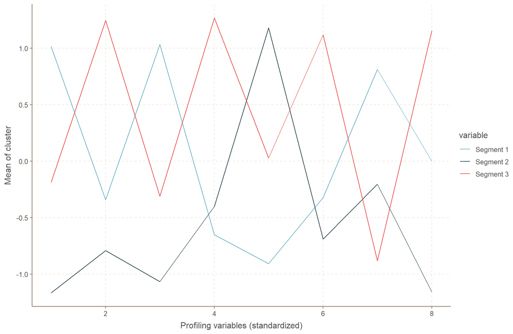

¿Podemos ver diferencias entre los segmentos? ¿Los segmentos difieren en términos del ingreso promedio y de que tan seguido visitan el mall? ¿Qué más podemos decir de esos segmentos?

Podemos también comparar los promedios de las variables de perfilación de cada segmento relativas al promedio de las variables respecto a toda la población. Esto también puede ayudarnos a entender mejor si hay clusters en los datos (por ej. si todos los segmentos se parecen a la población generalno deberían existir segmentos). Por ejemplo, quisieramos medir las razones entre los promedios de cada clusters con los promedios de la población y substraer 1 ( `avg(cluster)` `/` `avg(population)` `- 1`) y explorar la matriz:

|  | Segment 1 | Segment 2 | Segment 3 |
| --- | --- | --- | --- |
| V1 | 0.49 | -0.57 | -0.09 |
| V2 | -0.12 | -0.27 | 0.42 |
| V3 | 0.52 | -0.54 | -0.16 |
| V4 | -0.24 | -0.15 | 0.46 |
| V5 | -0.46 | 0.59 | 0.01 |
| V6 | -0.11 | -0.23 | 0.38 |
| Income | 0.30 | -0.08 | -0.33 |
| Mall.Visits | 0.00 | -0.69 | 0.69 |

> Cuanto más lejos sea una proporción a 0, más importante será ese atributo para un segmento relativo a la población total.

Tanto el gráfico de serpiente como esta matriz de valores relativos de los atributos de perfilamiento para cada cluster son maneras de visualizar nuestros segmentos e interpretarlos.

## Paso 8: Análisi de Robustes

El proceso de segmentación descrito hasta ahora puede ser seguido por muchos diferentes enfoques, por ejemplo:

- usando diferentes subconjuntos de los datos originales
- usando variaciones de los atributos de segmentación originales
- usando diferentes métricas de distancia
- usando diferentes métodos de segmentación
- usando diferentes números de clusters

> Así como cualquier análisis de datos, la segmentación es un proceso iterativo con muchas variaciones de datos, métodos, números de clusters, y perfiles generados hasta que se alcance una solución satistactoria.

Claramente explorar todas las variaciones va más allá del alcance de estos apuntes. Pero si abordamos, sin embargo, un ejemplo de como evaluar la **robustez estadística** y la **estabilidad de interpretación** de los clusters encontrados usando dos enfoques diferentes: Kmeans y Clusterización Jerárquica, como se mencionó antes.

Dos evaluaciones básicas a efectuar son:

1. ¿Qué tanto se intersectan los clusters usando diferentes enfoques? Específicamente, ¿qué porcentaje de nuestras observaciones son las mismas entre diferentes soluciones de agrupamiento?
2. ¿Qué tan parecidos son los perfiles de los segmentos encontrados? Específicamente, ¿qué tan parecidos son los promedios de los atributos de perfilamiento de los clústeres encontrados usando diferentes enfoques?

Cómo podemos tener pertenencias a grupos de todos los modelos de clusterización, podemos medir tanto el porcentaje total de observaciones que permanecen en el mismo cluster como el porcentaje de cada cluster de forma separada. Por ejemplo, para las dos soluciones de 3-segmentos encontradas (una con Kmeans y otra con Clusterización Jerárquica), esos porcentajes son los siguientes:

| Total | Segment 1 | Segment 2 | Segment 3 |
| --- | --- | --- | --- |
| 100 | 100 | 100 | 100 |

Claramente, usando diferente número de clusters puede llevar a diferentes porcentajes de intersección (pruebe por ejemplo usando 2 clusters): la robustez de nuestra solución puede también indicar cuantos clusters hay en nuestros datos - **si hay**. Sin embargo, en general no hay un “correcto porcentaje de interscción”, ya que esto depende de que tan difícil pueda ser el agrupamiento (por ej: considere el caso donde un cluster de series de tiempo de precios de acciones): la robustez de nuestra solución es frecuentemente “relativa a otras soluciones”. Por otro lado:

> Una segmentación sólida requiere eventualmente de robustez de nuestras decisiones a través de muchos “buenas” enfoques de clusterización utilizados.

Solo después de cierto número de evaluaciones de robustez, perfilamientos e interpretaciones, podemos tener una segmentación final. Durante el análisis de segmentación podríamos necesitar repetir el proceso múltiples veces, con muchas variaciones de las selecciones que hicimos en cada etapa del proceso, antes de alcanzar una solución final (si hay en efecto segmentos en nuestros datos) - la cual por supuesto puede ser revisada en cualquier punto en el futuro.

> Data Analytics es un proceso iterativo, por lo tanto podríamos necesitar retornar a nuestros datos originales en cualquier punto y seleccionar nuevos atributos así como nuevos clusters.

**Hasta entonces..**